# Permutation and Bootstrap Procedures

PSTAT 134 (Winter 2026)

Author

Affiliation

Sang-Yun Oh

University of California, Santa Barbara

## Data as a Distribution

We can make use of resampling methods to analyze data.

- Resampling methods treat data as an empirical distribution.
- Resample from data to create new samples.
- **Uncertainty quantification**: use bootstrappeddata to estimate variability of statistics.
- **Permutation testing**: use resampling to create null distributions for test statistics.

## Multivariate Mean and Covariance

- Let $X=(X_1, X_2, \cdots, X_p)^\top$ be a $p$-dimensional random vector.
- Mean vector is defined as (a column vector):
  $$\mu = E(X) =
  \begin{pmatrix}
  E\left(X_1\right) &
  \dots &
  E\left(X_p\right)
  \end{pmatrix}^\top=
  \begin{pmatrix}
  \mu_1 &
  \dots &
  \mu_p
  \end{pmatrix}^\top$$
- Covariance matrix $\Sigma=\left(\Sigma_{j k}\right)$[^1] is defined as
  $$\begin{aligned}
  \Sigma &= E\left[(X-\mu)(X-\mu)^\top\right]\\
  &=
  \left(E\left[(X_j-\mu_j)(X_k-\mu_k)\right]\right)\\
  &=\left(\Sigma_{j k}\right),
  \end{aligned}$$
  where $j, k=1,2, \cdots, p$.

## Sample Mean and Covariance

- Data matrix $\mathbf{X}$ has size $n\times p$ (i.e., $n$ observations of $p$ measurements).
- Sample mean vector is
  $$\overline{\mathbf{x}}=\left(\bar{x}_1, \bar{x}_2, \cdots, \bar{x}_p\right)^\top$$
- Sample covariance matrix $\mathbf{S}=\left(S_{j k}\right)$
  $$\begin{aligned}
  S_{j k}=\frac{1}{n} \sum_{i=1}^n\left(x_{i j}-\bar{x}_j\right)\left(x_{i k}-\bar{x}_k\right),
  \end{aligned}$$
  where $j, k=1,2, \cdots, p$

## Test Scores Data

- Test score data (Mardia, Kent and Bibby, 1979)

  ```
    mec vec alg ana sta
  1  77  82  67  67  81
  2  63  78  80  70  81
  3  75  73  71  66  81
  4  55  72  63  70  68
  ```

- 5 tests: *mechanics*, *vectors*, *algebra*, *analysis*, and *statistics* ($n=88$)
- First two tests were closed book, last three open book
- Score data as an $88 \times 5$ ($n\times p$) data matrix $\mathbf{X}$
- The $i$ th row of $\mathbf{X}$ is for student $i$:
  $$\mathbf{x}_i=\left(x_{i 1}, x_{i 2}, x_{i 3}, x_{i 4}, x_{i 5}\right).$$
- $\overline{\mathbf{x}}= \frac{1}{88}\sum_{i=1}^{88} \mathbf{x}$ is the vector of column means,
  $$\begin{aligned}
  \overline{\mathbf{x}} & =\left(\bar{x}_1, \bar{x}_2, \bar{x}_3, \bar{x}_4, \bar{x}_5\right) =(38.95,50.59,50.60,46.68,42.31)
  \end{aligned}$$
- Covariance matrix $\mathbf{G}=(G_{jk})$ is
  $$\mathbf{G}=\left(\begin{array}{ccccc}
  302.3 & 125.8 & 100.4 & 105.1 & 116.1 \\
  125.8 & 170.9 & 84.2 & 93.6 & 97.9 \\
  100.4 & 84.2 & 111.6 & 110.8 & 120.5 \\
  105.1 & 93.6 & 110.8 & 217.9 & 153.8 \\
  116.1 & 97.9 & 120.5 & 153.8 & 294.4
  \end{array}\right),$$
  where $G_{jk} = \frac{1}{88} \sum_{i=1}^{n} (x_{ij} - \bar{x}_j)(x_{ik} - \bar{x}_k)$

## Single Factor Model

- If only one factor $\mathbf{v} = (v_1, v_2, v_3, v_4, v_5)^\top$ affects all test scores,
- $\mathbf{v}$ is a fixed and each student’s scores can be modeled as
  $$\mathbf{x}_i = q_i \mathbf{v},$$
  where $q_i$ is a student-specific factor (e.g., “IQ”)
- Putting into a matrix form,
  $$\mathbf{X} = \mathbf{q} \mathbf{v}^\top,$$
  where $\mathbf{q} = (q_1, q_2, \cdots, q_n)^\top$ is an $n \times 1$ vector of factors
- How do we estimate and evaluate this model?
- Tasks: (1) estimate suitable $\mathbf{v}$, (2) quantify how much variance is explained by this model, and (3) assess the uncertainty of estimates.

## Eigenvalues and Eigenvectors of Covariance Matrix

- High correlations among test scores suggest underlying factors affecting student performance. PCA can help identify these factors.
- Covariance matrix $\mathbf{G}$ has 5 eigenvalues and eigenvectors.
- Eigenvalues ($\hat{\lambda}_i$): amount of variance explained by each PC.
- Eigenvectors ($\hat{\mathbf{v}}_i$): direction of each PC.

. . .

| Eigenvalue ($\hat{\lambda}_i$) | Eigenvector ($\hat{\mathbf{v}}_i$) |
| --- | --- |
| 679.2 | (.505, .368, .346, .451, .535) |
| 199.8 | (-.749, -.207, .076, .301, .548) |
| 102.6 | (-.300, .416, .145, .597, -.600) |
| 83.7 | (.296, -.783, -.003, .518, -.176) |
| 31.8 | (.079, .189, -.924, .286, .151) |

## Estimating the Single Factor Model

Single common factor can be extracted from principal Component Analysis (PCA) estimates. If the single factor model holds exactly, then:

- First eigenvector ($\hat{\mathbf{v}}_1$) of covariance matrix of $\mathbf{X}= \mathbf{q} \mathbf{v}^\top$ is $\mathbf{v}$[^2].
- Only ($\hat{\lambda}_1$) is positive; others are zero.
- All variance is explained by first PC:
  $$\hat{\theta} = \hat{\lambda}_1 / \sum_{i=1}^5 \hat{\lambda}_i=1.$$
- In practice, we rarely see $\hat{\theta} = 1$; real data is more complex.

## Task 1: Correctness of Single Factor Model

- For covariance matrix $\mathbf{G}$, $\hat{\lambda}_1 = 679.2$ and $\hat{\theta} = 0.619$
- One factor model doesn’t tell the whole story, but it’s a useful simplification.
- Adding more factors can improve fit, but increases complexity. (is it necessary?)
- Trade-off between model simplicity and accuracy is key in statistical modeling and data science.
- Is $q_i$ really an IQ? Probably not, but it captures overall student ability to first order.
- Next, we assess the uncertainty of $\hat{\theta}$ and $\hat{\mathbf{v}}_1$ using bootstrap (why?).

## Bootstrap Estimate of $\hat{\theta}$

- How accurate is $\hat{\theta} = 0.619$ as an estimate of $\theta$?
- We can use bootstrap to estimate standard error of $\hat{\theta}$,
- as long as we can compute $\hat{\theta}^*$ for bootstrap data set.
- Bootstrap data set is matrix $\mathbf{X}^*$ of size $88 \times 5$
- Rows $\mathbf{x}_i^*$ of $\mathbf{X}^*$ are a random sample from the rows of data matrix $\mathbf{X}$,
  $$\mathbf{x}_1^*=\mathbf{x}_{i_1}, \mathbf{x}_2^*=\mathbf{x}_{i_2}, \cdots, \mathbf{x}_{88}^*=\mathbf{x}_{i_{88}},$$
  where $i_1, i_2, \cdots, i_{88}$ are IID random integers from 1 to 88.

## Bootstrap Estimate of $\hat{\theta}$

- Compute the column means of $\mathbf{X}^*$, $\bar{x}_j^*=\frac{1}{88} \sum_{i=1}^{88} x_{i j}^* \quad j=1,2,3,4,5.$
- Bootstrap covariance matrix $\mathbf{G}^*$ is
  $$G_{j k}^*=\frac{1}{88} \sum_{i=1}^{88}\left(x_{i j}^*-\bar{x}_j^*\right)\left(x_{i k}^*-\bar{x}_k^*\right) \quad j, k=1,2,3,4,5 .$$
- Compute the eigenvalues of $\mathbf{G}^*$, namely $\hat{\lambda}_1^*, \hat{\lambda}_2^*, \cdots, \hat{\lambda}_5^*$,
  $$\hat{\theta}^*=\hat{\lambda}_1^* / \sum_{j=1}^5 \hat{\lambda}_j^*$$

## Bootstrap Estimate of $\hat{\theta}$

| Interval |
| --- |
| $\hat{\theta} \pm z^{(1-0.05)} \hat{\mathrm{se}} = [.542,\ .696]$ |
| $[\hat{\theta}^*_{(0.05)}, \hat{\theta}^*_{(0.95)}] = [.545,\ .693]$ |

## Additional Principal Components

First principal component: $\hat{\mathbf{v}}_1=(.51, .37, .35, .45, .54)$

- Assigns positive, similar weights to all test scores.
- Represents each student’s overall or average performance. Overall difficulty of tests.

. . .

Second principal component: $\hat{\mathbf{v}}_2=(-.75,-.21, .08, .30, .55)$

- Closed-book tests have negative and open-book have positive weights
- Measures contrast between open-book and closed-book performance.
- High $z$ score indicates much better performance on open-book tests compared to closed-book tests.

. . .

Estimating Uncertainty of Principal Components is Challenging. However, Bootstrap Can Help!

## Bootstrap Estimates of Principal Components

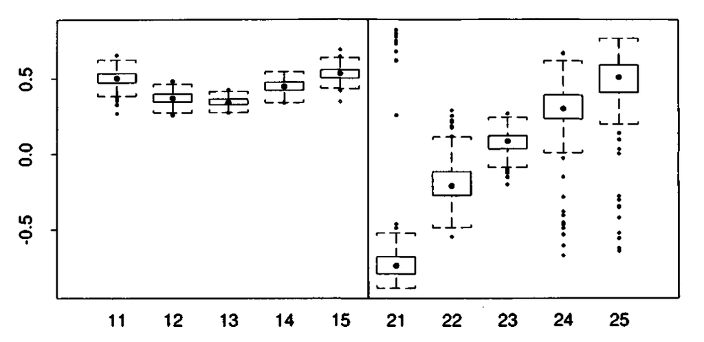

Bootstrap Estimates of Principal Components, $\hat{\mathbf{v}}_1$ (left panel) and $\hat{\mathbf{v}}_2$ (right panel) shows empirical distribution of the 200 bootstrap replications $\hat{v}_{i k}^*$.

## Comparing Bootstrap Standard Errors

- $\widehat{\operatorname{se}}_{200}$ bootstrap standard error with $B=200$ bootstrap replications
- $\widetilde{\operatorname{se}}_{B, \alpha}$ with $B=200$ and $\alpha$-cutoff: e.g., $\widetilde{s e}_{200,.90}$ and $\widetilde{s e}_{200,.95}$.

| First PC: $\hat{\mathbf{v}}_1$ | $\hat{v}_{11}$ | $\hat{v}_{12}$ | $\hat{v}_{13}$ | $\hat{v}_{14}$ | $\hat{v}_{15}$ |
| --- | --- | --- | --- | --- | --- |
| $\widehat{\operatorname{se}}_{200}$ | .057 | .045 | .029 | .041 | .049 |
| $\widetilde{\operatorname{se}}_{200, .84}$ | .055 | .041 | .028 | .041 | .047 |
| $\widetilde{\operatorname{se}}_{200, .90}$ | .055 | .041 | .027 | .042 | .046 |
| $\widetilde{\operatorname{se}}_{200, .95}$ | .054 | .048 | .029 | .040 | .047 |

. . .

| Second PC: $\hat{\mathbf{v}}_2$ | $\hat{v}_{21}$ | $\hat{v}_{22}$ | $\hat{v}_{23}$ | $\hat{v}_{24}$ | $\hat{v}_{25}$ |
| --- | --- | --- | --- | --- | --- |
| $\widehat{\operatorname{se}}_{200}$ | .189 | **.138** | .066 | .129 | **.150** |
| $\widetilde{\operatorname{se}}_{200, .84}$ | .078 | .122 | .064 | .110 | .114 |
| $\widetilde{\operatorname{se}}_{200, .90}$ | .084 | .129 | .067 | .111 | .125 |
| $\widetilde{\operatorname{se}}_{200, .95}$ | .080 | .130 | .066 | .114 | .120 |

## Bootstrap and Monte Carlo Simulation

- Bootstrap is a Monte Carlo method where we simulate data by resampling from observed data.
- Monte Carlo methods use random sampling to approximate complex mathematical or statistical problems: e.g., card games
- Monte Carlo methods are widely used in various fields, including finance, physics, and machine learning.
- Block Bootstrap: for time series or spatial data, resample blocks of consecutive observations to preserve dependence structure.
- Parametric Bootstrap: assume a parametric model for the data, estimate parameters, and generate bootstrap samples from the fitted model.
- Bayesian Bootstrap: use Bayesian methods to generate bootstrap samples, incorporating prior information about the data.

## Two-sample Permutation Test

- Comparison of two samples are commonly carried out by hypothesis testing: e.g., two sample t-test.
- Under the null hypothesis, the two samples are exchangeable.
- Construct the null distribution of the test statistic by first randomly permuting the labels of the two samples.

. . .

**NoteTwo-Sample Permutation Test**

- Pool the $m+n$ values
- repeat 9999 times
  - Draw a resample of size $m$ without replacement.
  - Use the remaining $n$ observations for the other sample.
  - Calculate the difference in means, or another statistic that compares samples.
- Plot a histogram of the random statistic values; show the observed statistic.
- Calculate the p-value as the fraction of times the random statistics exceed or equal the observed statistic (add 1 to numerator and denominator); multiply by 2 for a two-sided test.

## Verizon Data

- Verizon was an *Incumbent Local Exchange Carrier* (ILEC)
  - Responsible for maintaining land-line phone service in their area
  - Also sold long-distance service
- Competitors were termed *Competitive Local Exchange Carriers* (CLEC)
- When something went wrong, Verizon was responsible for all infrastructure repairs
- The New York Public Utilities Commission (PUC):
  - Monitored fairness by comparing repair times: ILEC vs. CLEC
  - Compared repair times for Verizon and different CLECs
  - Similar business structure for energy companies, etc.

## Verizon Data

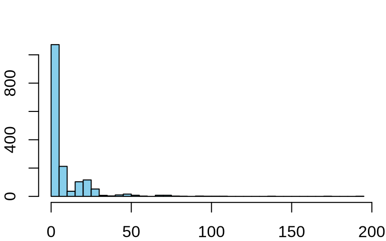

ILEC Histogram

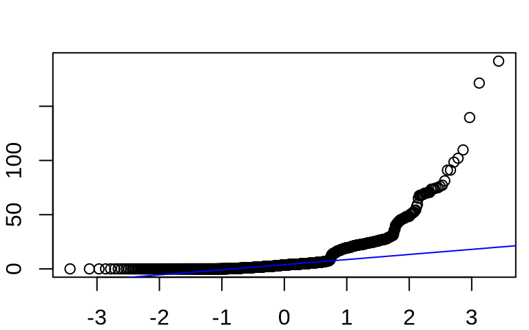

ILEC QQ Plot

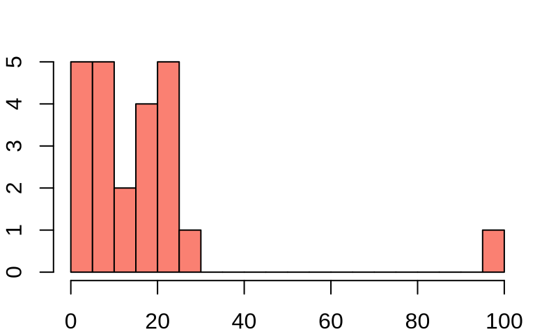

CLEC Histogram

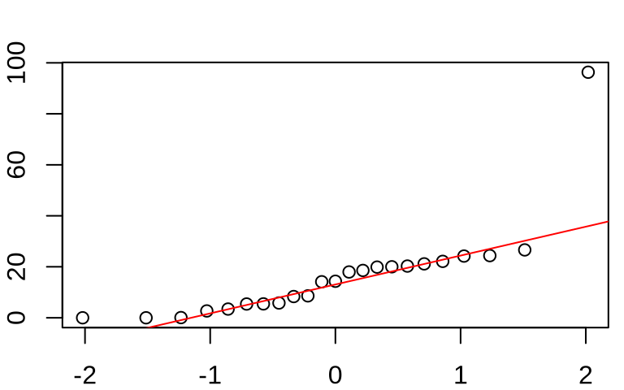

CLEC QQ Plot

## T-Test: Verizon Example

```r
# Perform a one-sided t-test (alternative: CLEC > ILEC)
t_test_result <- t.test(CLEC, ILEC, alternative = "greater")
t_test_result
```

```
    Welch Two Sample t-test

data:  CLEC and ILEC
t = 1.9834, df = 22.346, p-value = 0.02987
alternative hypothesis: true difference in means is greater than 0
95 percent confidence interval:
 1.091721      Inf
sample estimates:
mean of x mean of y
16.509130  8.411611
```

## Permutation Test: Verizon Example

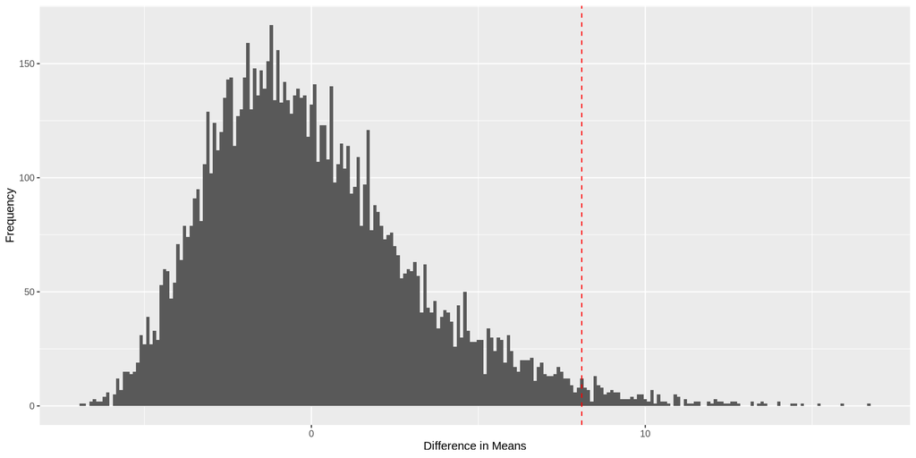

```r
# Calculate the observed difference in means
observed_diff <- mean(CLEC) - mean(ILEC)

set.seed(123)

# Function to perform permutation test
permutation_test <- function(data1, data2, num_permutations = 10000) {
  combined <- c(data1, data2)
  perm_diffs <- numeric(num_permutations)
  for (i in 1:num_permutations) {
    permuted <- sample(combined)
    perm_clec <- permuted[1:length(data1)]
    perm_ilec <- permuted[(length(data1) + 1):length(combined)]
    perm_diffs[i] <- mean(perm_clec) - mean(perm_ilec)
  }
  return(perm_diffs)
}

# Perform the permutation test
perm_diffs <- permutation_test(CLEC, ILEC)

# Calculate the p-value
p_value <- mean(abs(perm_diffs) >= abs(observed_diff))

# Plot the permutation distribution
perm_diffs_df <- data.frame(perm_diffs = perm_diffs)
ggplot(perm_diffs_df, aes(x = perm_diffs)) +
  geom_histogram(binwidth = 0.1) +
  geom_vline(aes(xintercept = observed_diff), color = "red", linetype = "dashed") +
  labs(x = "Difference in Means", y = "Frequency")
```

. . .

| Test | p-value |
| --- | --- |
| t-test | 0.0299 |
| Permutation | 0.0183 |

## Footnotes

[^1]: this notation for an indexed set is common in multivariate statistics
[^2]: show that this is true, assuming $\mathbf{X}$ is centered